# R Notebook

Name: Mayuri Patel

Email: mpate131@uncc.edu

title: “Lab2_AdvStats”

Question #1

In a population, there is 1/3 chance that a given person has a mutation in some gene.

You sample 30 people; what are the odds that exactly 12 of the people have the mutation? In R plot a probability density function (with dbinom) that shows the distribution for observing exactly (0,1,2,…30) people with the mutation.

What is the mean and variance for the expected number of people with the mutation.

- The probability to have a mutation is given as 1/3 (0.33).

```r
#The odds that exactly 12 people have mutation is:
#dbinom(k/x,n,prob=0.33)

dbinom(12,30,prob=0.33)
```

```
[1] 0.1067815
```

- So this means that there is a 10% chance that 12 people will be having the mutation from a sample of 30 people with a probability of 0.33.
- The R plot for probability density function for 0-30 people with mutation:

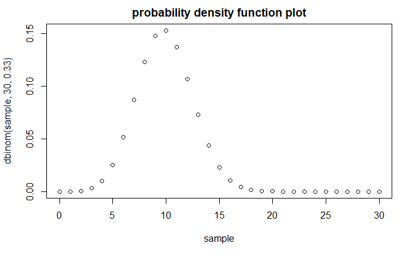

```r
#sample the data from 0-30 into a variable
sample <- 0:30

#PDF plot for the samples are:
plot(sample,dbinom(sample,30,0.33),main="probability density function plot")
```

- The mean and variance are:

```r
#The mean:
samp_mean <- mean(dbinom(sample,30,0.33))
print(paste("The Mean value is:", samp_mean))
```

```
[1] "The Mean value is: 0.032258064516129"
```

```r
#The variance:
samp_var <- var(dbinom(sample,30,0.33))
print(paste("The Variance value is:", samp_var))
```

```
[1] "The Variance value is: 0.00256465797965421"
```

Question #2

The background expected survival rate for a disease is 0.4. You are running a clinical trial. You have 100 patients on a new drug. 47 patients die (and 53 survive). From the bionomial test:

(2A) Plot out the probability density function with the x-axis the number of patients that survive under the null hypothesis.

(2B) What is the p-value for a null hypothesis that the drug has no effect.(Show the one line of R code that produces this p-value)

(2C) What is the p-value for a null hypothesis that the drug does not improve survival.(show you can get the same answer with binom.test(….) and sum(dbinom(….))

- The probability of expected survival rate for a disease is given as 0.4 with 53 patients surviving the disease.

2A:

```r
#The number of patients survived is stored in a variable
survived <- c(0:53)
#Calculating the dbinom for each survived patients
dbinom(survived,100,prob=0.4)
```

```
 [1] 6.533186e-23 4.355457e-21 1.437301e-19 3.130122e-18 5.060364e-17 6.477266e-16 6.837114e-15 6.120845e-14 4.743655e-13 3.232713e-12 1.961179e-11 1.069734e-10 5.289241e-10
[14] 2.386939e-09 9.888749e-09 3.779700e-08 1.338644e-07 4.409650e-07 1.355559e-06 3.900205e-06 1.053055e-05 2.674426e-05 6.402414e-05 1.447502e-04 3.096047e-04 6.274654e-04
[27] 1.206664e-03 2.204769e-03 3.832099e-03 6.342785e-03 1.000750e-02 1.506506e-02 2.165603e-02 2.974969e-02 3.908293e-02 4.913282e-02 5.914136e-02 6.819905e-02 7.537790e-02
[40] 7.988768e-02 8.121914e-02 7.923819e-02 7.420719e-02 6.672895e-02 5.762955e-02 4.781118e-02 3.811036e-02 2.919091e-02 2.148776e-02 1.520222e-02 1.033751e-02 6.756543e-03
[53] 4.244495e-03 2.562714e-03
```

- Plot of PDF:

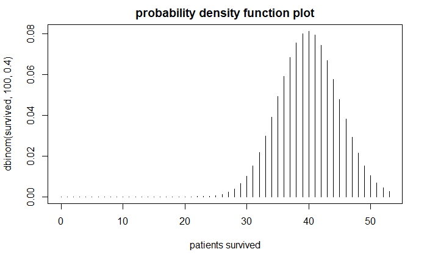

```r
#plot for survived patients in PDF:
plot(survived,dbinom(survived,100,0.4),type='h',main="probability density function plot", xlab="patients survived")
```

2B:

- The null hypothesis that drug has no effect and alternative being that drug has effect. Because of this, the alternative is two-tailed test (two.sided). The P-value for 53 patients is calculated using binom.test.

```r
#Here, taking 53 surviving patients with its probability
binom.test(53,100,0.4,alternative = "two.sided")
```

```
    Exact binomial test

data:  53 and 100
number of successes = 53, number of trials = 100, p-value = 0.01036
alternative hypothesis: true probability of success is not equal to 0.4
95 percent confidence interval:
 0.4275815 0.6305948
sample estimates:
probability of success
                  0.53
```

- The P-value for a null hypothesis that the drug has no effect is 0.01

2C:

```r
#Here,taking 47 die patients with its probability as 0.6
binom.test(47,100,0.6,alternative = "less")
```

```
    Exact binomial test

data:  47 and 100
number of successes = 47, number of trials = 100, p-value = 0.005761
alternative hypothesis: true probability of success is less than 0.6
95 percent confidence interval:
 0.0000000 0.5569147
sample estimates:
probability of success
                  0.47
```

```r
#Altenative to binom.test can be done using sum(binom())
sum(dbinom(0:47,100,0.6))
```

```
[1] 0.005760648
```

```r
pbinom(47,100,0.6)
```

```
[1] 0.005760648
```

- The Resultant p-value from binom.test and sum(dbinom()) are same as 0.0057

Question #3

(3A) Use the rbinom function to simulate 1,000 experiments in which 10,000 patients are sampled with a 1/2 chance of seeing a mutation. (You should get 1,000 numbers back with each # the # of patients from the 10,000 that had the mutation…) (What is the one line of r-code that would produce myVals?)

(3B) What is the expected mean and variance of the vector in (3A). Show that the actual mean and variance are close to the expected mean and variance.

(3C) Take the vector that results from (3A). For each element in that vector, calculate a p-value with binom.test(….)$p.value for the null hypothesis that the frequency of the allele in the population for that experiment is 1/2.

Graph the histogram of all of those p-values. What distribution would you expect? Is that what you see?

(3D) Change the expected value of 1/2 in (3C) to some other value. What happens to the p-values in the histogram. Would you expect the same shape of the p-value histogram with expected values of .49 as with .51? Why or why not?

- The probability of seeing a mutation is given as 0.5.

3A:

```r
#The one line code:
#rbinom simulate the random numbers from 1 to 10000 with a limit of 1000 return numbers.
exp <- rbinom(1000,10000,p=0.5)
#This shows the first few numbers of exp variable
head(exp)
```

```
[1] 4967 5002 4898 5023 5013 5050
```

```r
#This gives the total length of the variable exp
length(exp)
```

```
[1] 1000
```

3B:

```r
#The mean is:
mean(exp)
```

```
[1] 5000.191
```

```r
#The variance is:
var(exp)
```

```
[1] 2455.928
```

```r
#here, n= sample size, p=probability
#mean = np
exp_mean <- 10000*0.5
exp_mean
```

```
[1] 5000
```

```r
#variance = np(1-p)
exp_var <- 10000*0.5*(1-0.5)
exp_var
```

```
[1] 2500
```

- The actual mean and variance are close to the expected mean and variance as can be seen in the above code result.

3C:

- Taking exp variable from 3A and calculating p-value for each of them

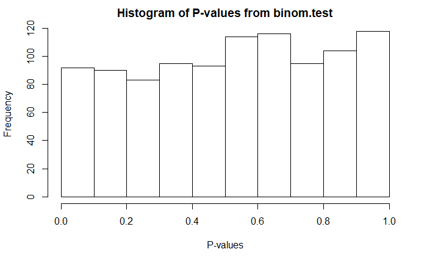

```r
#exp variable that calculate rbinom
exp <- rbinom(1000,10000,p=0.5)
#An empty variable to store all the p-values generated from for loop
pval <- c()
#looping the exp sample
for (i in exp){
  test = binom.test(i,10000,0.5) # using binom.test to generate p-value
  pval <- c(pval, test$p.value) # taking p-value from the binom.test and stored into pval variable
}

#generating the histogram using all the p-values.
hist(pval, main="Histogram of P-values from binom.test",xlab="P-values")
```

3D:

- Changing the probability value from 0.5 to 0.49

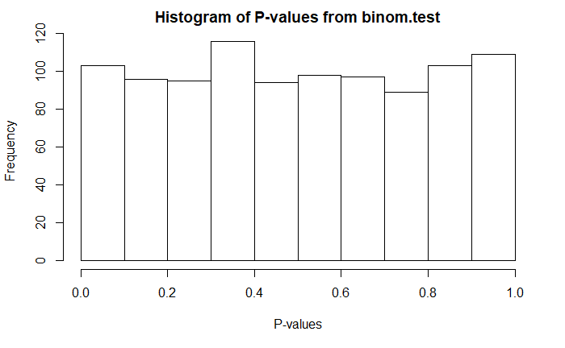

```r
#exp variable that calculate rbinom
exp <- rbinom(1000,10000,p=0.49)
#An empty variable to store all the p-values generated from for loop
pval <- c()
#looping the exp sample
for (i in exp){
  test = binom.test(i,10000,0.49) # using binom.test to generate p-value
  pval <- c(pval, test$p.value) # taking p-value from the binom.test and stored into pval variable
}

#generating the histogram using all the p-values.
hist(pval,main="Histogram of P-values from binom.test",xlab="P-values")
```

- Changing the probability value from 0.5 to 0.51

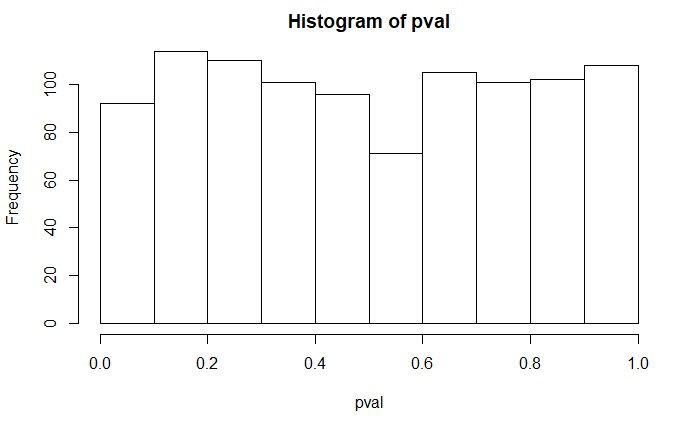

```r
#exp variable that calculate rbinom
exp <- rbinom(1000,10000,p=0.51)
#An empty variable to store all the p-values generated from for loop
pval <- c()
#looping the exp sample
for (i in exp){
  test = binom.test(i,10000,0.51) # using binom.test to generate p-value
  pval <- c(pval, test$p.value) # taking p-value from the binom.test and stored into pval variable
}

#generating the histogram using all the p-values.
hist(pval)
```

- The p-values in the histogram remained almost the same with a minor change. The shape of p-values in the histogram is almost same in all the three cases of probability - 0.5,0.49 and 0.51. This happens because there is minor change in the probability value.